# Probability and Statistics

# Lab Assignment 1: Naive Bayes Classifier

### *Tymur Krasnianskyi, Olha Hahurna, Anastasiia Petrovych*

## Introduction

During the past three weeks, we learned a couple of essential notions and theorems, and one of the most important among them is the *Bayes theorem*.

One of its applications is **Naive Bayes classifier**, which is a probabilistic classifier whose aim is to determine which class some observation probably belongs to by using the Bayes formula:
$$\mathsf{P}(\mathrm{class}\mid
\mathrm{observation})=\frac{\mathsf{P}(\mathrm{observation}\mid\mathrm{class})\mathsf{P}(\mathrm{class})}{\mathsf{P}(\mathrm{observation})}$$

Under the strong independence assumption, one can calculate $\mathsf{P}(\mathrm{observation} \mid \mathrm{class})$ as
$$\mathsf{P}(\mathrm{observation}) =
\prod_{i=1}^{n} \mathsf{P}(\mathrm{feature}_i), \qquad
\mathsf{P}(\mathrm{observation} \mid \mathrm{class}) = \prod_{i=1}^{n}
\mathsf{P}(\mathrm{feature}_i \mid \mathrm{class}),$$
where $n$ is the total number of features describing a given observation. Thus, $\mathsf{P}(\mathrm{class}|\mathrm{observation})$ now can be calculated as

$$\mathsf{P}(\mathrm{class} \mid
\mathrm{\mathrm{observation}}) = \mathsf{P}(\mathrm{class})\times
\prod_{i=1}^{n}\frac{\mathsf{P}(\mathrm{feature}_i\mid
\mathrm{class})}{\mathsf{P}(\mathrm{feature}_i)}\tag{1}$$

## Data description

- **2 - fake news** This data set contains data of American news: a headline and an abstract of the article. Each piece of news is classified as fake or credible. The task is to classify the news from test.csv as credible or fake.

Each data set consists of two files: *train.csv* and *test.csv*. The first one you will need find the probabilities distributions for each of the features, while the second one is needed for checking how well your classifier works.

```r
library(ggwordcloud)
# here goes a list of recommended libraries,
# though you may install other ones if they are needed
library(tidytext)
library(readr)
library(dplyr)
library(ggplot2)
library(zeallot)
```

### Data pre-processing

```r
list.files(getwd())
```

```
## [1] "2-fake_news"
## [2] "data"
## [3] "intro-R.Rmd"
## [4] "Lab1_Naive_Bayes_Classifier_Templatee.Rmd"
## [5] "Lab1_Naive_Bayes.Rproj"
## [6] "stop_words.txt"
```

```r
list.files("lab1")
```

```
## character(0)
```

```r
test_path <- "2-fake_news/test.csv"
train_path <- "2-fake_news/train.csv"

stop_words <- read_file("stop_words.txt")
#list_of_words <- stop_words[[1]]
# https://stackoverflow.com/questions/27195912/why-does-strsplit-return-a-list
splitted_stop_words <- strsplit(stop_words, split='\n')
splitted_stop_words <- splitted_stop_words[[1]]
stop_words <- splitted_stop_words
```

```r
train <-  read.csv(file = train_path, stringsAsFactors = FALSE)
test <-  read.csv(file = test_path, stringsAsFactors = FALSE)
```

```r
# note the power functional features of R bring us!
tidy_text1 <- unnest_tokens(test, 'Headline', 'Body', token="words") %>%
             filter(!Headline %in% stop_words)
tidy_text2 <- unnest_tokens(train, 'Headline', 'Body', token="words") %>%
             filter(!Headline %in% stop_words)


unique_words = unique(tidy_text2$Headline)
e <- new.env()
e$new_labels <- rep(0, times = nrow(test))
e$guess_counter <- 0
e$total_predictions <- 0
```

## Classifier implementation

```r
naiveBayes <- setRefClass("naiveBayes",

       # here it would be wise to have some vars to store intermediate result
       # frequency dict etc. Though pay attention to bag of wards!
       fields = list(
       ),

       methods = list(

                    # prepare your training data as X - bag of words for each of your
                    # messages and corresponding label for the message encoded as 0 or 1
                    # (binary classification task)
                    fit = function(table)
                    {
                      all_credible_words <- table %>% filter(Label == "credible")
                      count_in_credible <- all_credible_words %>% count(Headline,sort=TRUE)
                      e$copy_credible_words <- count_in_credible
                      number_of_credible_words = length(all_credible_words$Label)
                      all_fake_words = table %>% filter(Label == "fake")
                      count_in_fake <- all_fake_words %>% count(Headline,sort=TRUE)
                      e$copy_fake_words <- count_in_fake
                      e.count_in_credible <- count_in_credible
                      e.count_in_fake <- count_in_fake
                      number_of_fake_words = length(all_fake_words$Label)
                      number_of_all_words = number_of_credible_words + number_of_fake_words

                      range1 = nrow(count_in_credible)
                      for(row in seq(range1)) {
                        credible_probability = strtoi(count_in_credible[row, 2])/number_of_credible_words
                        count_in_credible[row, 2] <- credible_probability
                      }
                      range2 = nrow(count_in_fake)
                      for(row in seq(range2)) {
                        fake_probability = strtoi(count_in_fake[row, 2])/number_of_fake_words
                        count_in_fake[row, 2] <- fake_probability
                      }
                      return(list(count_in_credible, count_in_fake))


                    },

                    # return prediction for a single message
                    predict = function(message, credible_table, fake_table, number_of_all_words, number_of_credible_words, number_of_fake_words)
                    {

                      message_table = tidy_text1 %>% filter(X == message)
                      message_words = message_table$Headline
                      fake_probability_for_message = 1
                      credible_probability_for_message = 1
                      counter = 1
                      for(word in message_words) {
                        fake_probability <- fake_table[word,]
                        credible_probability  <- credible_table[word,]
                        fake_if_word = ((number_of_fake_words/number_of_all_words) * fake_probability)/ (((number_of_fake_words/number_of_all_words) * fake_probability) + ((number_of_credible_words/number_of_all_words) * credible_probability))
                        credible_if_word = ((number_of_credible_words/number_of_all_words) * (credible_probability))/ (((number_of_fake_words/number_of_all_words) * fake_probability) + ((number_of_credible_words/number_of_all_words) * (credible_probability)))


                        if(is.na(fake_if_word) == FALSE & is.na(credible_if_word) == FALSE) {
                          credible_probability_for_message = credible_probability_for_message * credible_if_word
                          fake_probability_for_message = fake_probability_for_message * fake_if_word
                        }
                        counter = counter + 1
                      }
                      if(fake_probability_for_message < credible_probability_for_message) {
                        return(1)
                      }
                      else {
                        return (0)
                      }

                    },


                    build_prediction_table = function(data_table, credible_table, fake_table) {
                      number_of_credible_words <- nrow(credible_table)
                      number_of_fake_words = nrow(fake_table)
                      number_of_all_words = number_of_credible_words + number_of_fake_words
                      message_numbers = data_table$X
                      counter = 1
                      for(number in message_numbers) {
                        a = predict(number, credible_table, fake_table, number_of_all_words, number_of_credible_words, number_of_fake_words)
                        if(a == 1) {
                          e$new_labels[counter] = "credible"
                        }
                        else {
                          e$new_labels[counter] = "fake"
                        }
                        counter = counter + 1
                      }
                    },

                    # score you test set so to get the understanding how well you model
                    # works.
                    # look at f1 score or precision and recall
                    # visualize them
                    # try how well your model generalizes to real world data!
                    score = function(X_test, y_test)
                    {
                        result <- (X_test == y_test)
                        e$a <- table(result)
                        bad_results <- e$a[names(e$a)==FALSE]
                        return(bad_results/length(result))
                    }
))

model = naiveBayes()
c(credible_words_probabilities, fake_words_probabilities) %<-% model$fit(tidy_text2)
credible_words_probabilities <- data.frame(credible_words_probabilities[, -1], row.names = credible_words_probabilities$Headline)
fake_words_probabilities <- data.frame(fake_words_probabilities[, -1], row.names = fake_words_probabilities$Headline)
model$build_prediction_table(test, credible_words_probabilities, fake_words_probabilities)
result_data_frame <- data.frame(test$Headline, e$new_labels)
result <- model$score(test$Label, result_data_frame$e.new_labels)
print(result)
```

```
##     FALSE
## 0.1970075
```

### Data visualization

```
## Some words could not fit on page. They have been removed.
```

[figure not shown]

```r
set.seed(18102022)

WORD_LIMIT <- 500

view_count_in_credible <- head(e$copy_credible_words, WORD_LIMIT)
ggplot(view_count_in_credible, aes(label = Headline, size = n, color =  factor(sample.int(100, nrow(view_count_in_credible), replace = TRUE)))) +
  geom_text_wordcloud_area(rm_outside = TRUE) +
  scale_size_area(max_size = 10) +
  theme_minimal() +
  ggtitle("Credible words")
```

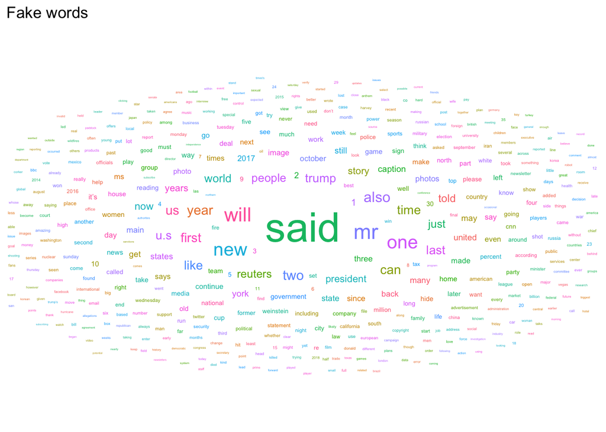

```r
view_count_in_fake <- head(e$copy_fake_words, WORD_LIMIT)
ggplot(view_count_in_fake, aes(label = Headline, size = n, color = factor(sample.int(23913, nrow(view_count_in_fake), replace = TRUE)))) +
  geom_text_wordcloud_area(rm_outside = TRUE) +
  scale_size_area(max_size = 12) +
  theme_minimal() +
  ggtitle("Fake words")
```

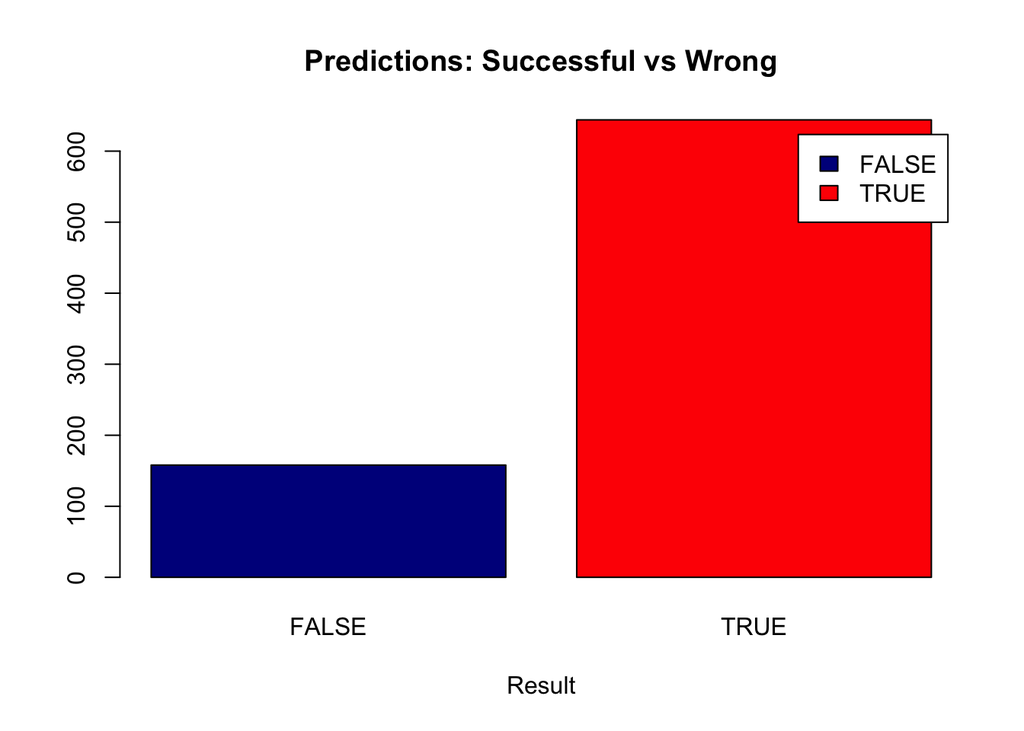

```r
barplot(e$a, main="Predictions: Successful vs Wrong",
  xlab="Result", col=c("darkblue","red"),
  legend = rownames(e$a)
  )
```